[← Back to Conference Project](https://www.kameronyork.com/projects/conference/inspire-change.html)

# Other Insights

Below are insights I have found from the General Conference data used in my previous article. Unlike the insights shown previously I was either unable to find statistical evidence to prove their significance or I could not determine a concrete reason why the events were transpiring. Enjoy!

### Family History and Genealogy

(“Family History”, “Genealogy”)

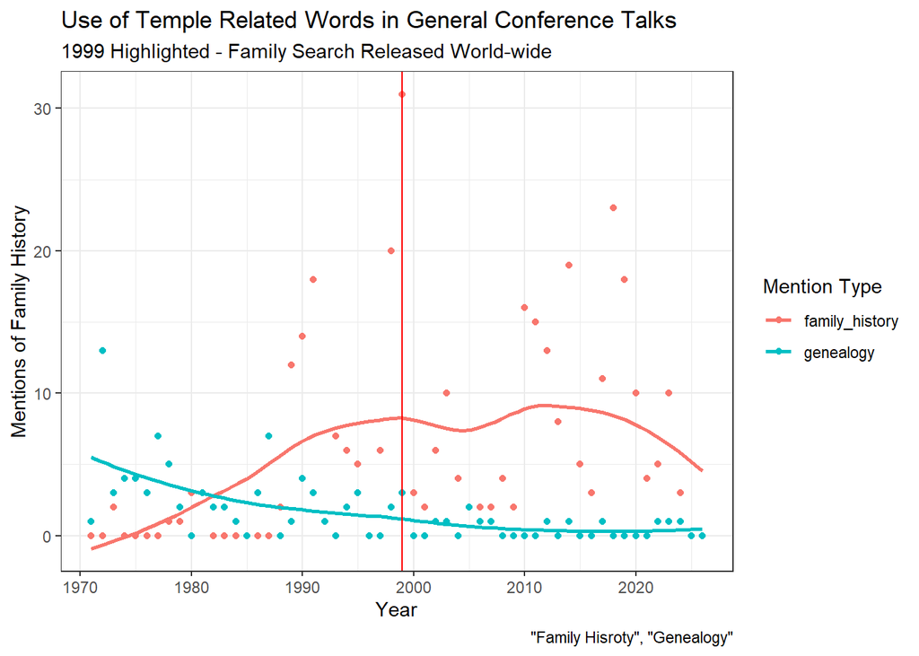

A quite interesting relationship has been found in the terms that are used for studying ancestry. The 1970’s preferred the term, “Genealogy” to describe this effort, but as the years passed it was quickly replaced by a most descriptive, “Family History”. This was doubled during the time of the worldwide release of, “Family Search” - the free family history service provided by the Church - in the year 1999.

By 2010 the term, “Genealogy” was nearly completely phased out of General Conference messages. This change was not due to any intervention from church leaders, but by the culture shift in the church as a whole.

### Gospel of Jesus Christ

(“Faith”, “Repentance”, “Baptism”, “Gift of the Holy Ghost”, “Endure to the End”)

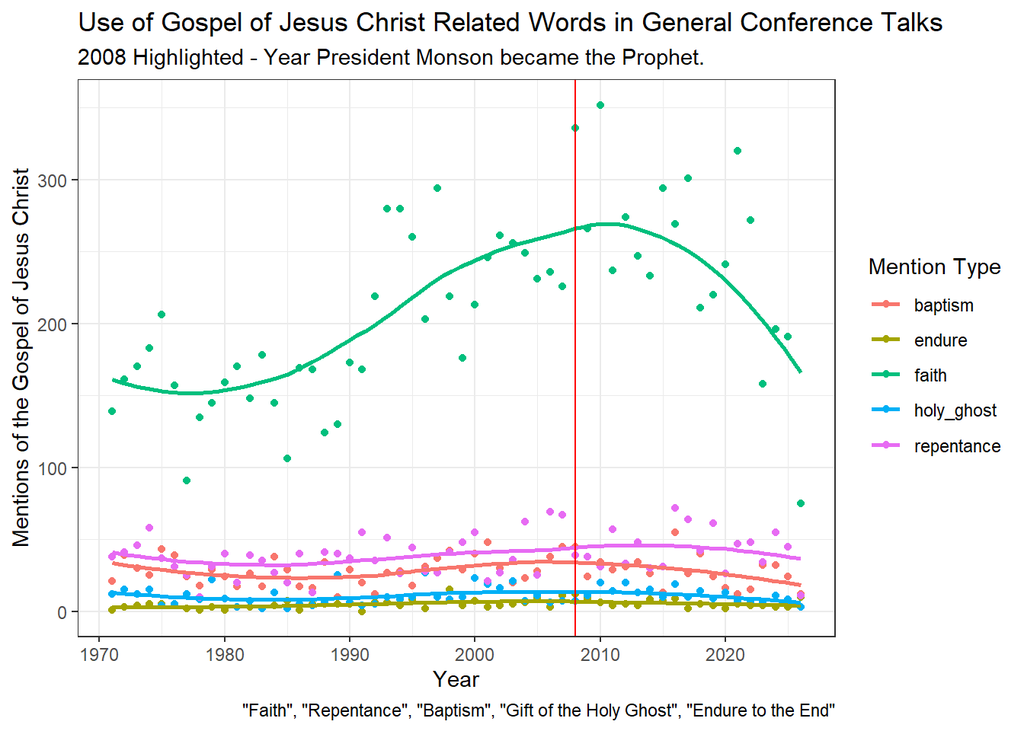

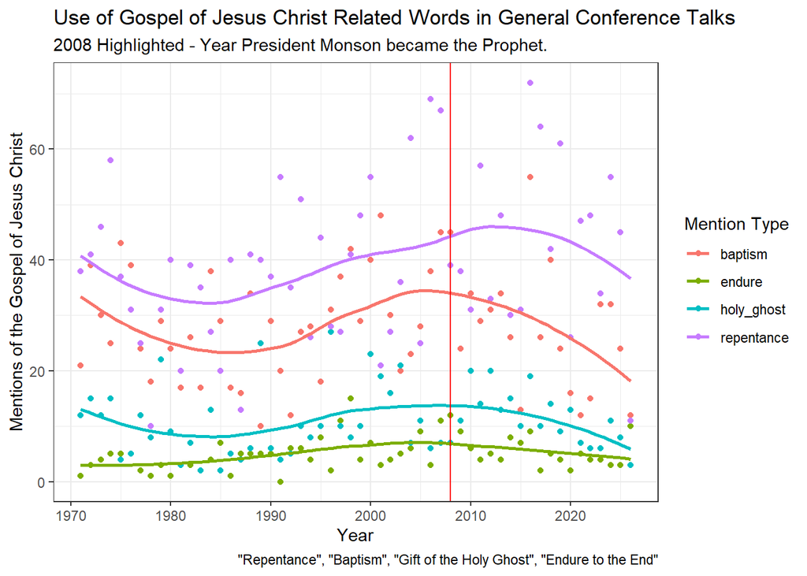

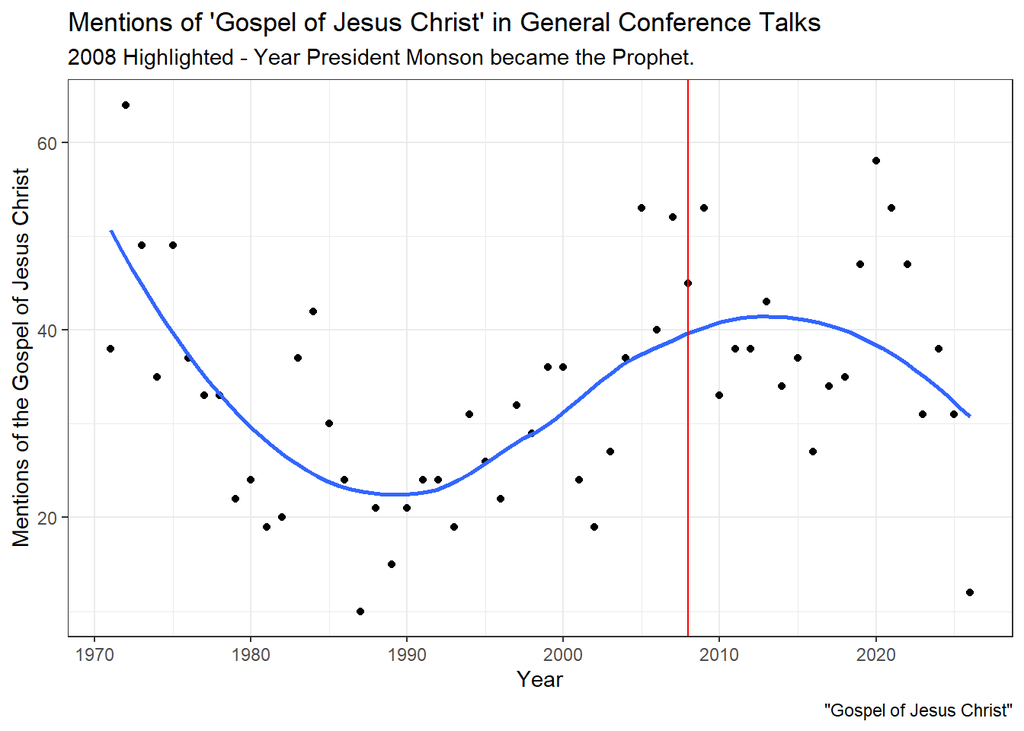

### Satan

(“Satan”, “Adversary”)

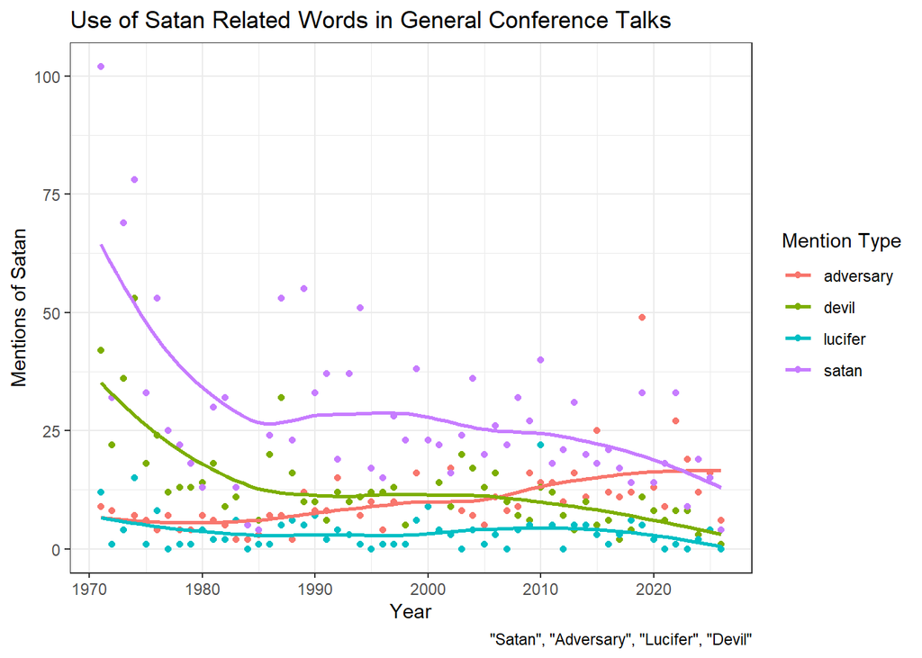

Interestingly we have seen a large decrease in use of the words, “Satan”, and “Lucifer” in General Conference talks in the past 50 years. However, the word, “Adversary” is on the rise, having now overtaken “Satan” in some conferences.

This is an interesting observation, but I am unsure of what could be causing it!

### Jesus

(“Jesus”, “Lord”, “Savior”)

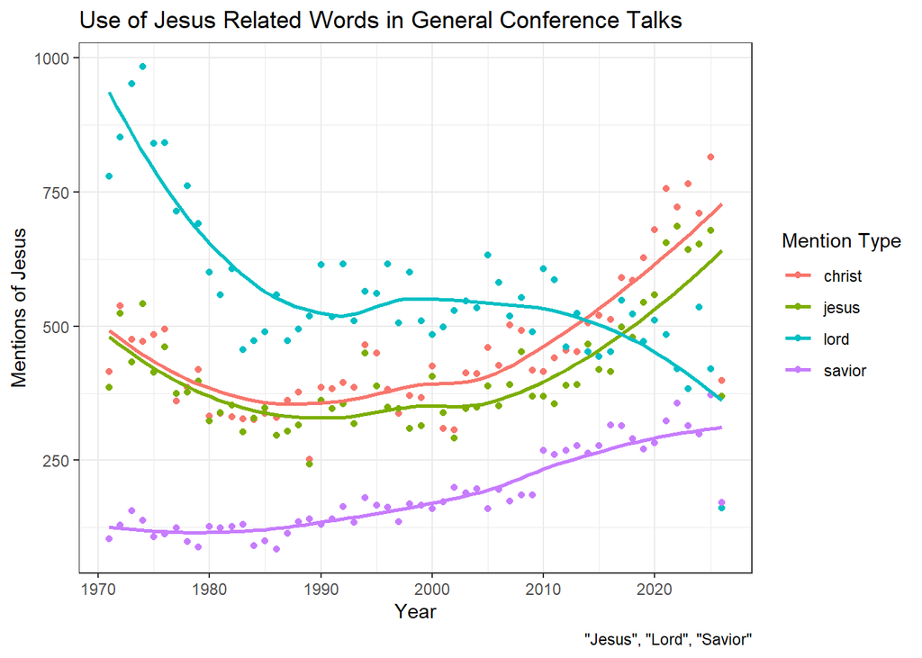

### Prophet Names

(“President Nelson”, “Russell M. Nelson”, “Russell Nelson”)

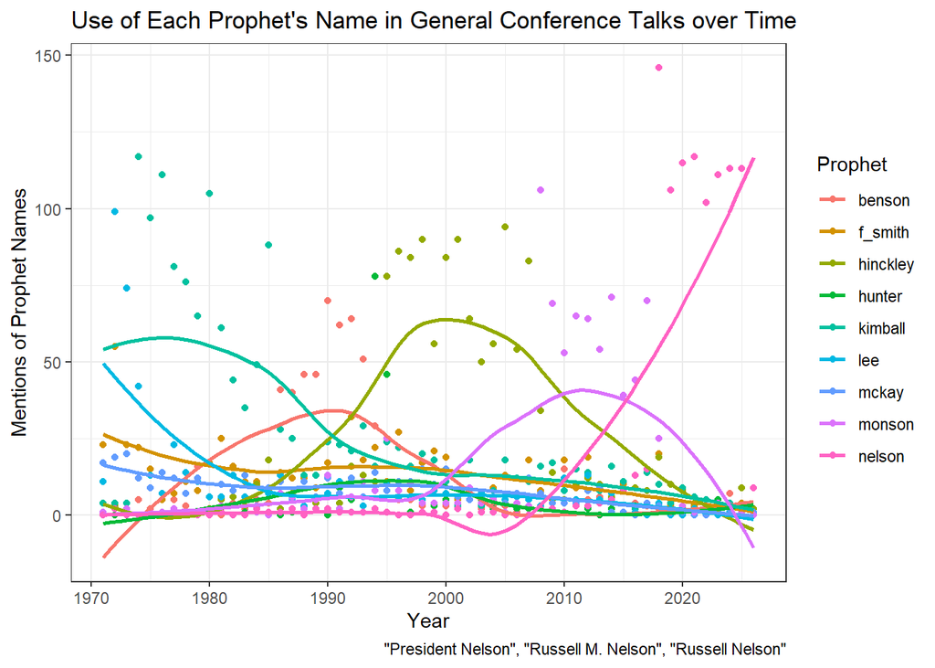

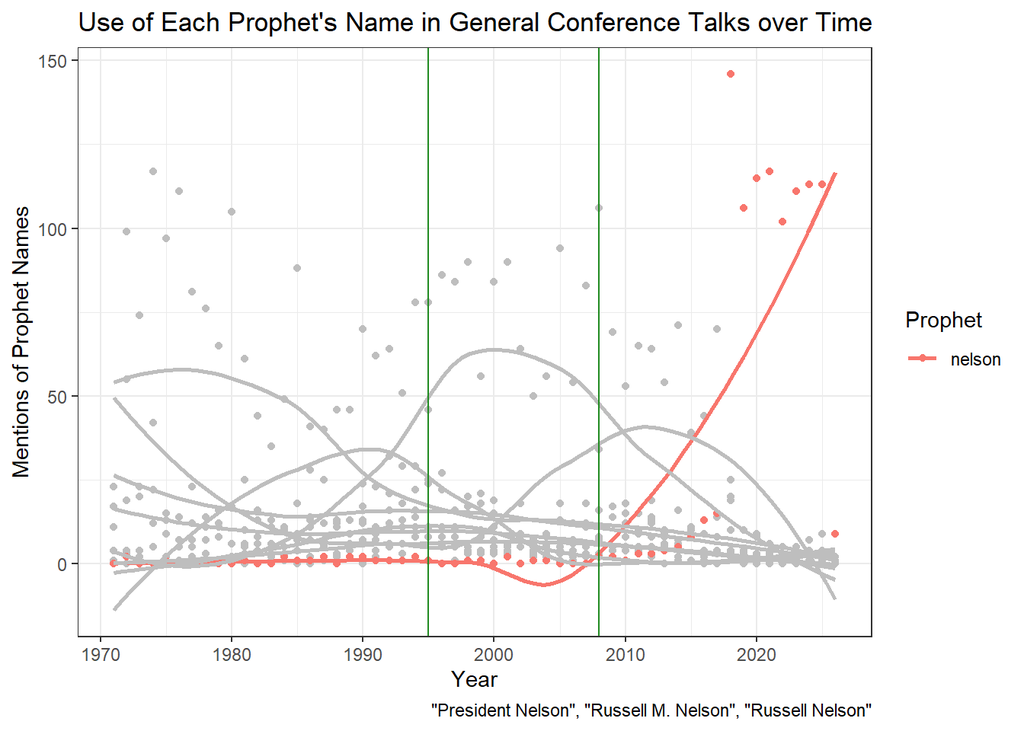

### Relief Society President Names

(“President Bingham”, “Jean B. Bingham”, “Jean Bingham”, “Sister Bingham”)

[interactive chart not shown]

### Jesus and God

(“God”, “Heavenly Father”, “Father in Heaven” | “Jesus”, “Lord”, “Savior”)

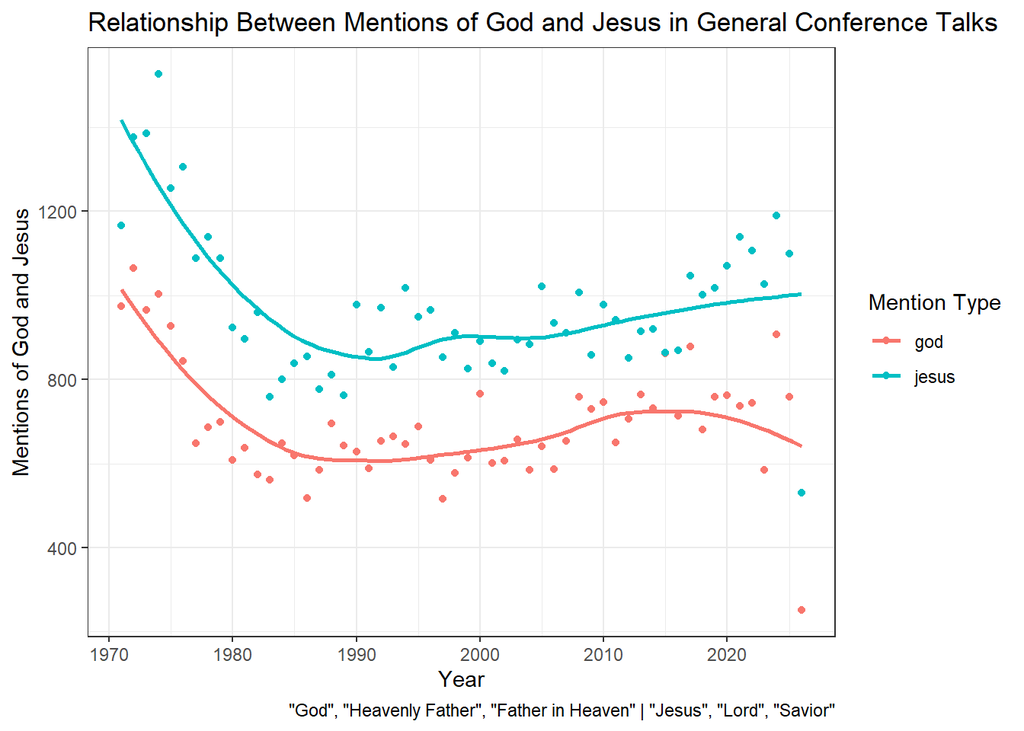

### Jesus and God

(“God” | “Jesus”)

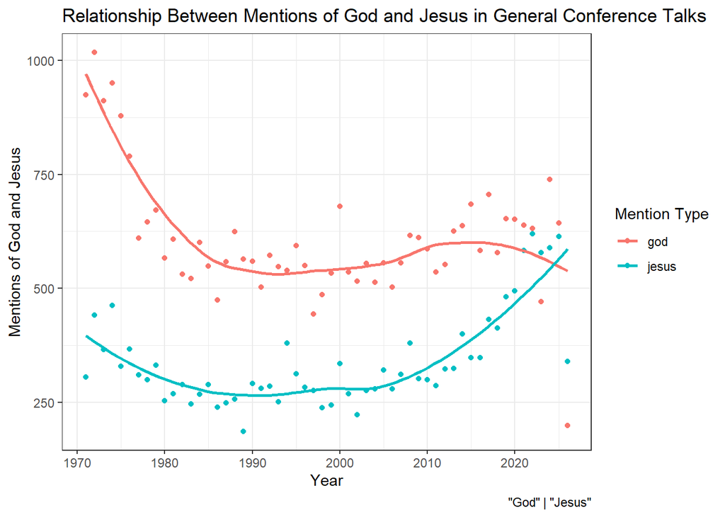

### The Official Name of the Church

(“The Church of Jesus Christ of Latter-Day Saints”)

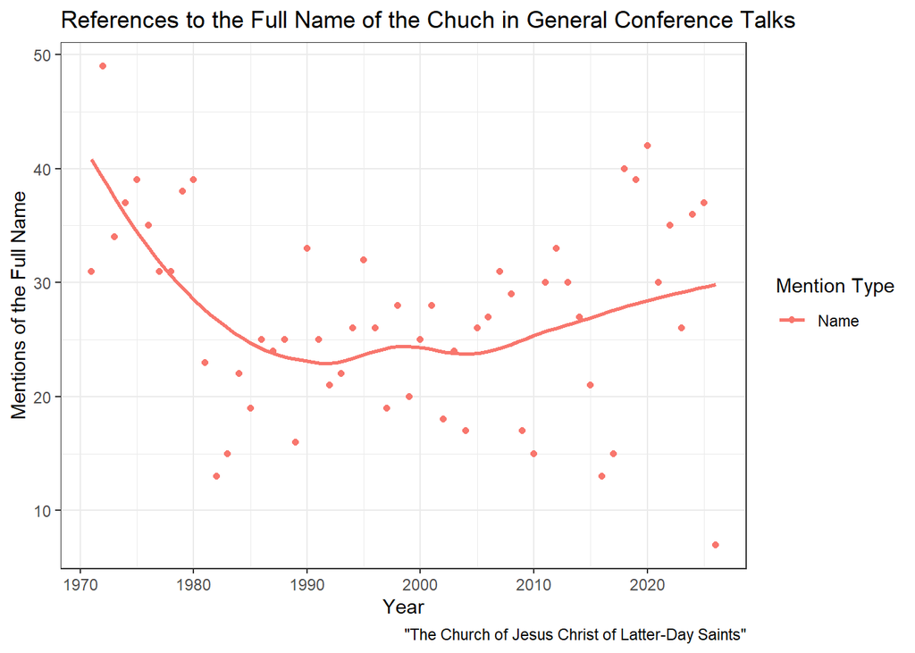

Compared to other names of the Church: (“Mormon Church”, “LDS Church”)

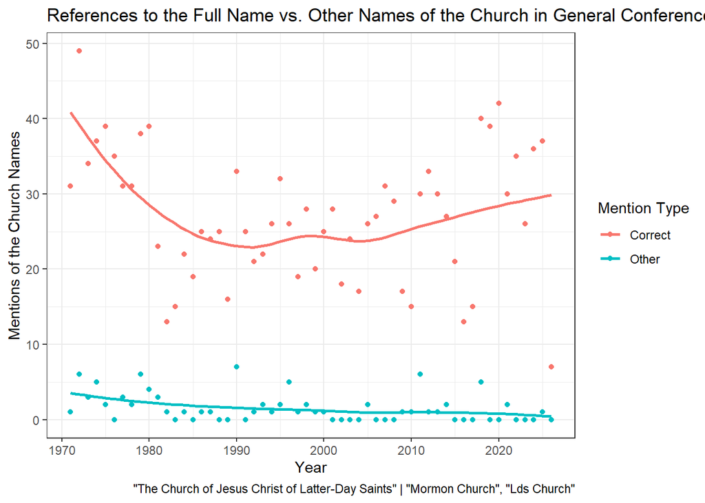